# TaskD

Task D: Implementing Machine Learning Algorithms (deadline: 12/2 Mon)

In this task, you will explore several machine learning algorithms to gain hands-on experience with both supervised and unsupervised learning. Follow the instructions below to complete each part of the task. Instructions Watch the Video Tutorials Begin by watching the video tutorials we have provided. These videos introduce key concepts in machine learning and provide examples of how to apply different algorithms effectively.

Download the Dataset Download this dataset: data.csv The dataset contains information on students' demographics, academic performance, and other factors. For a full description of each feature, refer to the dataset details provided here.

Task Requirements Using K-Nearest Neighbors (KNN) Algorithm Tips: Use the features provided to train and test your model, and aim to predict the Target variable.

Using Linear Regression Algorithm

Tips: Apply linear regression to predict a continuous variable in the dataset, such as Admission Grade or GPA. You can also evaluate the model's performance using appropriate metrics (e.g., Mean Absolute Error, R-squared).

(Bonus) Using Unsupervised Learning Tips: Attempt to cluster the data based on specific features (e.g., demographics or academic background) and interpret the resulting groups.

For each task, provide evaluation metrics and create the visualization of your results!

Task D：實現機器學習演算法（截止日期：12/2 星期一）

在這個任務中，您將探索多種機器學習演算法，藉此獲得監督學習和非監督學習的實際操作經驗。請依照以下指示完成任務的每一部分。

任務說明 觀看教學影片 首先，請觀看我們提供的教學影片。這些影片會介紹機器學習的關鍵概念，並提供如何有效應用不同演算法的範例。

下載數據集 請下載此數據集：data.csv 數據集包含學生的人口統計、學術表現及其他因素的相關資訊。如需瞭解每個特徵的完整描述，請參考[這裡](https://archive.ics.uci.edu/dataset/697/predict+students+dropout+and+academic+success)提供的數據集詳情。

任務要求 使用 K-最近鄰（K-Nearest Neighbors，KNN）演算法

提示：利用提供的特徵來訓練和測試您的模型，目標是預測 Target 變數。 使用線性迴歸（Linear Regression）演算法

提示：應用線性迴歸來預測數據集中的連續變數，例如入學分數（Admission Grade）或 GPA。您還可以使用適當的指標（例如平均絕對誤差 Mean Absolute Error、R-squared）來評估模型表現。 （額外挑戰）使用非監督學習

提示：嘗試根據特定特徵（例如人口統計或學術背景）對數據進行分群，並解釋分群的結果。

# 1. K-Nearest Neighbors (KNN)

```python
import pandas as pd
```

```python
file_path = 'data.csv'
data = pd.read_csv(file_path, delimiter=';')
```

```python
data
```

|  | Marital status | Application mode | Application order | Course | Daytime/evening attendance\t | Previous qualification | Previous qualification (grade) | Nacionality | Mother's qualification | Father's qualification | ... | Curricular units 2nd sem (credited) | Curricular units 2nd sem (enrolled) | Curricular units 2nd sem (evaluations) | Curricular units 2nd sem (approved) | Curricular units 2nd sem (grade) | Curricular units 2nd sem (without evaluations) | Unemployment rate | Inflation rate | GDP | Target |
| --- | --- | --- | --- | --- | --- | --- | --- | --- | --- | --- | --- | --- | --- | --- | --- | --- | --- | --- | --- | --- | --- |
| 0 | 1 | 17 | 5 | 171 | 1 | 1 | 122.0 | 1 | 19 | 12 | ... | 0 | 0 | 0 | 0 | 0.000000 | 0 | 10.8 | 1.4 | 1.74 | 0 |
| 1 | 1 | 15 | 1 | 9254 | 1 | 1 | 160.0 | 1 | 1 | 3 | ... | 0 | 6 | 6 | 6 | 13.666667 | 0 | 13.9 | -0.3 | 0.79 | 2 |
| 2 | 1 | 1 | 5 | 9070 | 1 | 1 | 122.0 | 1 | 37 | 37 | ... | 0 | 6 | 0 | 0 | 0.000000 | 0 | 10.8 | 1.4 | 1.74 | 0 |
| 3 | 1 | 17 | 2 | 9773 | 1 | 1 | 122.0 | 1 | 38 | 37 | ... | 0 | 6 | 10 | 5 | 12.400000 | 0 | 9.4 | -0.8 | -3.12 | 2 |
| 4 | 2 | 39 | 1 | 8014 | 0 | 1 | 100.0 | 1 | 37 | 38 | ... | 0 | 6 | 6 | 6 | 13.000000 | 0 | 13.9 | -0.3 | 0.79 | 2 |
| ... | ... | ... | ... | ... | ... | ... | ... | ... | ... | ... | ... | ... | ... | ... | ... | ... | ... | ... | ... | ... | ... |
| 4419 | 1 | 1 | 6 | 9773 | 1 | 1 | 125.0 | 1 | 1 | 1 | ... | 0 | 6 | 8 | 5 | 12.666667 | 0 | 15.5 | 2.8 | -4.06 | 2 |
| 4420 | 1 | 1 | 2 | 9773 | 1 | 1 | 120.0 | 105 | 1 | 1 | ... | 0 | 6 | 6 | 2 | 11.000000 | 0 | 11.1 | 0.6 | 2.02 | 0 |
| 4421 | 1 | 1 | 1 | 9500 | 1 | 1 | 154.0 | 1 | 37 | 37 | ... | 0 | 8 | 9 | 1 | 13.500000 | 0 | 13.9 | -0.3 | 0.79 | 0 |
| 4422 | 1 | 1 | 1 | 9147 | 1 | 1 | 180.0 | 1 | 37 | 37 | ... | 0 | 5 | 6 | 5 | 12.000000 | 0 | 9.4 | -0.8 | -3.12 | 2 |
| 4423 | 1 | 10 | 1 | 9773 | 1 | 1 | 152.0 | 22 | 38 | 37 | ... | 0 | 6 | 6 | 6 | 13.000000 | 0 | 12.7 | 3.7 | -1.70 | 2 |

4424 rows × 37 columns

```python
# 計算相關性，找出重要的特徵
import seaborn as sns
import matplotlib.pyplot as plt

# 計算相關性
correlation_matrix = data.corr()
print(correlation_matrix['Target'].sort_values(ascending=False))
```

```
Target                                            1.000000
Curricular units 2nd sem (approved)               0.624157
Curricular units 2nd sem (grade)                  0.566827
Curricular units 1st sem (approved)               0.529123
Curricular units 1st sem (grade)                  0.485207
Tuition fees up to date                           0.409827
Scholarship holder                                0.297595
Curricular units 2nd sem (enrolled)               0.175847
Curricular units 1st sem (enrolled)               0.155974
Admission grade                                   0.120889
Displaced                                         0.113986
Previous qualification (grade)                    0.103764
Curricular units 2nd sem (evaluations)            0.092721
Application order                                 0.089791
Daytime/evening attendance\t                      0.075107
Curricular units 2nd sem (credited)               0.054004
Curricular units 1st sem (credited)               0.048150
Curricular units 1st sem (evaluations)            0.044362
GDP                                               0.044135
Course                                            0.034219
Unemployment rate                                 0.008627
International                                     0.003934
Father's qualification                           -0.001393
Father's occupation                              -0.001899
Mother's occupation                              -0.005629
Educational special needs                        -0.007353
Nacionality                                      -0.014801
Inflation rate                                   -0.026874
Mother's qualification                           -0.043178
Previous qualification                           -0.056039
Curricular units 1st sem (without evaluations)   -0.068702
Marital status                                   -0.089804
Curricular units 2nd sem (without evaluations)   -0.094028
Application mode                                 -0.221747
Gender                                           -0.229270
Debtor                                           -0.240999
Age at enrollment                                -0.243438
Name: Target, dtype: float64
```

```python
# 編碼目標變數
from sklearn.preprocessing import LabelEncoder, StandardScaler

le = LabelEncoder()
data['Target'] = le.fit_transform(data['Target'])
```

```python
# 選擇前六相關作為特徵
features_knn = [
    'Curricular units 2nd sem (approved)', 'Curricular units 2nd sem (grade)',
    'Curricular units 1st sem (approved)', 'Curricular units 1st sem (grade)',
    'Tuition fees up to date', 'Scholarship holder'
]
X_knn = data[features_knn].fillna(0)
y_knn = data['Target']
```

```python
X_knn
```

|  | Curricular units 2nd sem (approved) | Curricular units 2nd sem (grade) | Curricular units 1st sem (approved) | Curricular units 1st sem (grade) | Tuition fees up to date | Scholarship holder |
| --- | --- | --- | --- | --- | --- | --- |
| 0 | 0 | 0.000000 | 0 | 0.000000 | 1 | 0 |
| 1 | 6 | 13.666667 | 6 | 14.000000 | 0 | 0 |
| 2 | 0 | 0.000000 | 0 | 0.000000 | 0 | 0 |
| 3 | 5 | 12.400000 | 6 | 13.428571 | 1 | 0 |
| 4 | 6 | 13.000000 | 5 | 12.333333 | 1 | 0 |
| ... | ... | ... | ... | ... | ... | ... |
| 4419 | 5 | 12.666667 | 5 | 13.600000 | 1 | 0 |
| 4420 | 2 | 11.000000 | 6 | 12.000000 | 0 | 0 |
| 4421 | 1 | 13.500000 | 7 | 14.912500 | 1 | 1 |
| 4422 | 5 | 12.000000 | 5 | 13.800000 | 1 | 1 |
| 4423 | 6 | 13.000000 | 6 | 11.666667 | 1 | 0 |

4424 rows × 6 columns

```python
# 標準化數據
scaler = StandardScaler()
X_knn_scaled = scaler.fit_transform(X_knn)
```

```python
X_knn_scaled
```

```
array([[-1.47152688, -1.96348862, -1.52125739, -2.19710239,  0.36813532,
        -0.57491418],
       [ 0.51890369,  0.65956171,  0.41804989,  0.6935986 , -2.71639244,
        -0.57491418],
       [-1.47152688, -1.96348862, -1.52125739, -2.19710239, -2.71639244,
        -0.57491418],
       ...,
       [-1.13978845,  0.62757329,  0.74126777,  0.88201036,  0.36813532,
         1.73939004],
       [ 0.18716526,  0.33967752,  0.09483201,  0.65230287,  0.36813532,
         1.73939004],
       [ 0.51890369,  0.53160803,  0.41804989,  0.2118151 ,  0.36813532,
        -0.57491418]])
```

```python
from sklearn.model_selection import train_test_split
# 分割數據集
X_train_knn, X_test_knn, y_train_knn, y_test_knn = train_test_split(
    X_knn_scaled, y_knn, test_size=0.4, random_state=88
)
```

```python
from sklearn.neighbors import KNeighborsClassifier
# 訓練 KNN 模型
knn = KNeighborsClassifier()
knn.fit(X_train_knn, y_train_knn)
y_pred_knn = knn.predict(X_test_knn)
```

```
KNN model evaluation:
              precision    recall  f1-score   support

           0       0.73      0.76      0.74       576
           1       0.37      0.30      0.33       305
           2       0.79      0.82      0.80       889

    accuracy                           0.71      1770
   macro avg       0.63      0.63      0.63      1770
weighted avg       0.70      0.71      0.70      1770

Confusion Matrix:
```

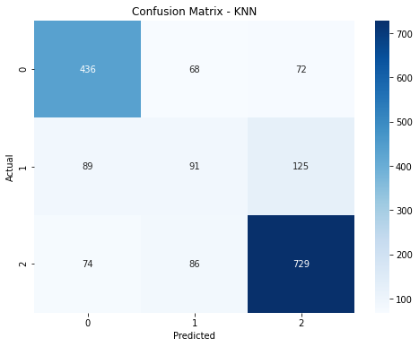

```python
from sklearn.metrics import classification_report, confusion_matrix

# 評估 KNN 模型
print("KNN model evaluation:")
print(classification_report(y_test_knn, y_pred_knn))
print("Confusion Matrix:")
conf_matrix = confusion_matrix(y_test_knn, y_pred_knn)

plt.figure(figsize=(8, 6))
sns.heatmap(conf_matrix, annot=True, fmt='d', cmap='Blues', xticklabels=le.classes_, yticklabels=le.classes_)
plt.xlabel('Predicted')
plt.ylabel('Actual')
plt.title('Confusion Matrix - KNN')
plt.show()
```

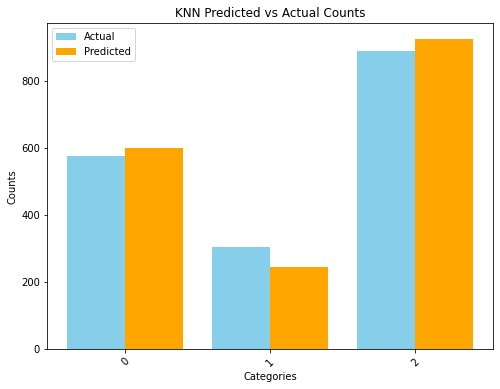

```python
# 統計實際值與預測值的數量
actual_counts = np.bincount(y_test_knn)
predicted_counts = np.bincount(y_pred_knn)

# 確保兩者長度相同
max_length = max(len(actual_counts), len(predicted_counts))
actual_counts = np.pad(actual_counts, (0, max_length - len(actual_counts)), 'constant')
predicted_counts = np.pad(predicted_counts, (0, max_length - len(predicted_counts)), 'constant')

# 繪製長條圖
categories = le.inverse_transform(range(max_length))
x = np.arange(len(categories))

plt.figure(figsize=(8, 6))
plt.bar(x - 0.2, actual_counts, width=0.4, label='Actual', color='skyblue')
plt.bar(x + 0.2, predicted_counts, width=0.4, label='Predicted', color='orange')
plt.xticks(x, categories, rotation=45)
plt.xlabel('Categories')
plt.ylabel('Counts')
plt.title('KNN Predicted vs Actual Counts')
plt.legend()
plt.show()
```

# 2. Linear Regression

```python
# 計算相關性
correlation_matrix = data.corr()
print(correlation_matrix['Admission grade'].sort_values(ascending=False))
```

```
Admission grade                                   1.000000
Previous qualification (grade)                    0.580444
Previous qualification                            0.184183
Target                                            0.120889
Curricular units 2nd sem (approved)               0.076659
Curricular units 2nd sem (grade)                  0.074402
Curricular units 1st sem (grade)                  0.073868
Curricular units 1st sem (approved)               0.070892
Tuition fees up to date                           0.054132
Curricular units 1st sem (credited)               0.040829
Curricular units 2nd sem (credited)               0.040225
Unemployment rate                                 0.038756
Nacionality                                       0.028176
International                                     0.025274
Scholarship holder                                0.018881
Curricular units 1st sem (without evaluations)    0.009033
Gender                                            0.008315
Daytime/evening attendance\t                      0.007970
Displaced                                        -0.000543
Marital status                                   -0.004771
Curricular units 2nd sem (without evaluations)   -0.013254
Application mode                                 -0.013271
Debtor                                           -0.014423
Educational special needs                        -0.018306
GDP                                              -0.019519
Inflation rate                                   -0.021624
Age at enrollment                                -0.029915
Curricular units 1st sem (enrolled)              -0.033251
Father's occupation                              -0.037733
Mother's occupation                              -0.040186
Curricular units 2nd sem (enrolled)              -0.041878
Father's qualification                           -0.051972
Mother's qualification                           -0.054412
Curricular units 2nd sem (evaluations)           -0.057132
Curricular units 1st sem (evaluations)           -0.072059
Application order                                -0.096930
Course                                           -0.125058
Name: Admission grade, dtype: float64
```

```python
# 用先前學歷的成績預測入學成績
X = data[['Previous qualification (grade)']].fillna(0)  # 特徵
y = data['Admission grade']  # 目標變數
```

```python
# 分割資料集
X_train, X_test, y_train, y_test = train_test_split(X, y, test_size=0.3, random_state=66)
```

```python
from sklearn.linear_model import LinearRegression
from sklearn.metrics import mean_absolute_error, r2_score
```

```python
# 訓練模型
lr_model = LinearRegression()
lr_model.fit(X_train, y_train)
```

```
LinearRegression()
```

```python
# 預測
y_pred = lr_model.predict(X_test)
```

```python
y_pred
```

```
array([120.26138144, 127.22710718, 122.16112482, ..., 119.62813364,
       138.62556748, 115.19539908])
```

```python
# 評估模型
mae = mean_absolute_error(y_test, y_pred)
r2 = r2_score(y_test, y_pred)
```

```python
print(lr_model.score(X, y))
print(lr_model.coef_)
print(lr_model.intercept_)
print(f"Mean Absolute Error (MAE): {mae}")
print(f"R-squared (R²): {r2}")
```

```
0.3369012176220598
[0.63324779]
43.00515050199543
Mean Absolute Error (MAE): 8.796689058521261
R-squared (R²): 0.32598221447522013
```

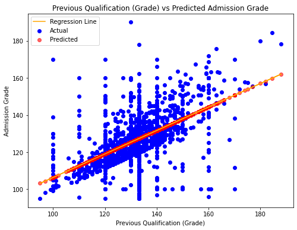

```python
# 實際值與預測值散點圖
plt.figure(figsize=(8, 6))
plt.scatter(X_test, y_test, color='blue', label='Actual')
plt.scatter(X_test, y_pred, color='red', label='Predicted', alpha=0.6)
plt.plot(X_test, y_pred, color='orange', label='Regression Line')
plt.xlabel('Previous Qualification (Grade)')
plt.ylabel('Admission Grade')
plt.title('Previous Qualification (Grade) vs Predicted Admission Grade')
plt.legend()
plt.show()
```

# 3. Unsupervised Learning - KMeans

```python
academic_features = [
    'Previous qualification (grade)',  # 先前學歷成績
    'Admission grade',                 # 入學成績
    'Curricular units 1st sem (grade)',# 第一學期成績
    'Curricular units 2nd sem (grade)',# 第二學期成績
    'Curricular units 1st sem (approved)', # 第一學期通過課程數
    'Curricular units 2nd sem (approved)'  # 第二學期通過課程數
]
X = data[academic_features].fillna(0)  # 填補缺失值
```

```python
# 標準化數據
scaler = StandardScaler()
X_scaled = scaler.fit_transform(X)
```

```python
# 應用 KMeans 模型進行分群
kmeans = KMeans(n_clusters=3, random_state=66)  # 假設分為3群
clusters = kmeans.fit_predict(X_scaled)

# 將分群結果加入原始數據
data['Cluster'] = clusters
```

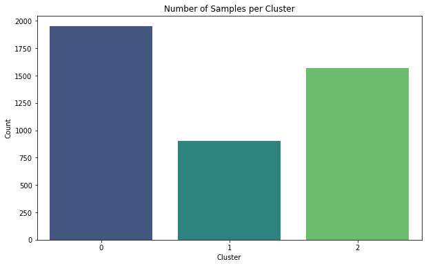

```python
# 分群結果
plt.figure(figsize=(10, 6))
sns.countplot(x='Cluster', data=data, palette='viridis')
plt.title('Number of Samples per Cluster')
plt.xlabel('Cluster')
plt.ylabel('Count')
plt.show()
```

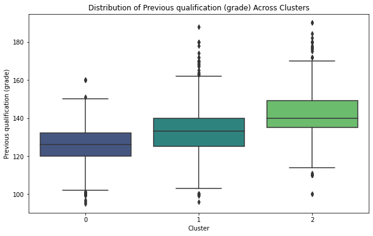

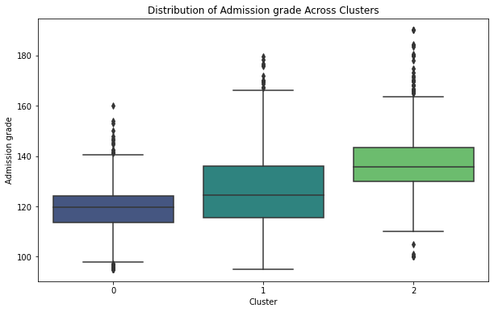

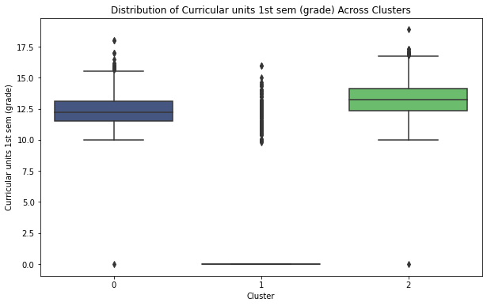

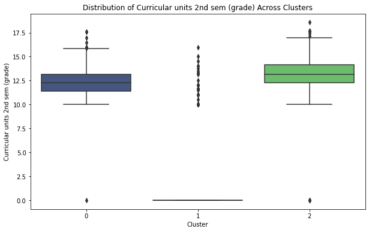

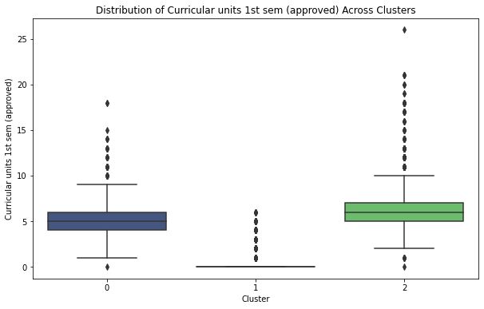

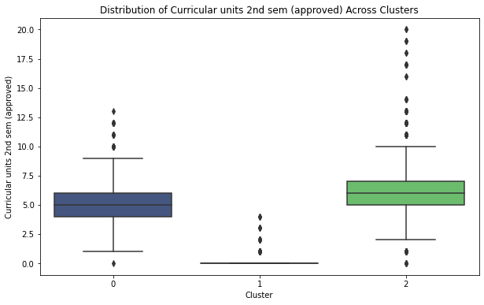

```python
# 特徵分布箱型圖
for feature in academic_features:
    plt.figure(figsize=(10, 6))
    sns.boxplot(data=data, x='Cluster', y=feature, palette='viridis')
    plt.title(f'Distribution of {feature} Across Clusters')
    plt.xlabel('Cluster')
    plt.ylabel(feature)
    plt.show()
```

```python
# 群體特徵分析
cluster_summary = data.groupby('Cluster')[academic_features].mean()
print("Cluster Summary:")
print(cluster_summary)
```

```
Cluster Summary:
         Previous qualification (grade)  Admission grade  \
Cluster
0                            124.999231       118.687852
1                            132.382080       126.178982
2                            142.214404       137.747228

         Curricular units 1st sem (grade)  Curricular units 2nd sem (grade)  \
Cluster
0                               12.336600                         12.340088
1                                2.453119                          0.517865
2                               13.249629                         13.202529

         Curricular units 1st sem (approved)  \
Cluster
0                                   5.121989
1                                   0.511062
2                                   6.607393

         Curricular units 2nd sem (approved)
Cluster
0                                   4.901589
1                                   0.076327
2                                   6.368388
```

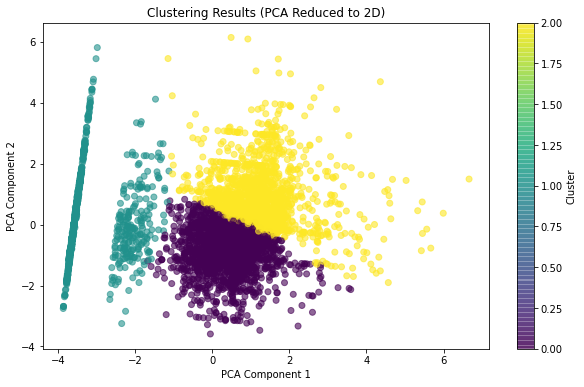

```python
from sklearn.decomposition import PCA

# 使用 PCA 降維至 2D
pca = PCA(n_components=2)
X_pca = pca.fit_transform(X_scaled)

# 繪製散點圖
plt.figure(figsize=(10, 6))
plt.scatter(X_pca[:, 0], X_pca[:, 1], c=data['Cluster'], cmap='viridis', alpha=0.6)
plt.colorbar(label='Cluster')
plt.title('Clustering Results (PCA Reduced to 2D)')
plt.xlabel('PCA Component 1')
plt.ylabel('PCA Component 2')
plt.show()
```

## Explanation of Clustering Results:

The clustering was based on students' academic backgrounds, including Previous qualification (grade), Admission grade, Curricular units 1st sem (grade), Curricular units 2nd sem (grade), Curricular units 1st sem (approved), Curricular units 2nd sem (approved).